# Project CS-711

## Numerical Variables

Now we will handle numerical variables which includes continous and finite features

```python
num_feat = [f for f in df.columns if (df[f].dtype!="O") and f not in encoded_cols]
num_feat
```

```
['Instrument',
 'MTM Exposure',
 'Book Exposure',
 '1-Year Likelihood',
 'Severity Used',
 'Commitment',
 'Time to Maturity',
 'Capital - EL Tail Risk Contribution (Capped)',
 'Capitalization Rate - EL Tail Risk Contribution',
 'Asset Recovery Correlation',
 'Recovery R-Squared for Simulation',
 'Asset R-Squared for Simulation']
```

```python
finite_features = [f for f in num_feat if len(df[f].unique()) <= 30]
# Features with unique values upto 30.
```

```python
finite_features
```

```
['1-Year Likelihood', 'Severity Used']
```

```python
print(len(df["Severity Used"].unique()))
print(len(df["1-Year Likelihood"].unique()))
```

```
9
17
```

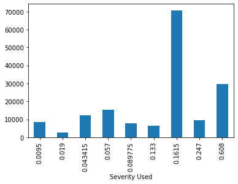

```python
df.groupby("Severity Used")["Capital - EL Tail Risk Contribution (Capped)"].mean().plot.bar()
```

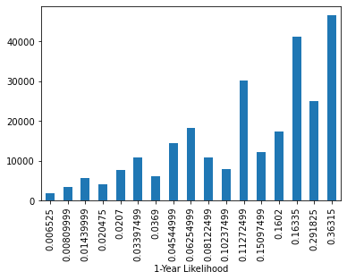

```python
df.groupby("1-Year Likelihood")["Capital - EL Tail Risk Contribution (Capped)"].mean().plot.bar()
```

##### We can see there is relation between Target Capital and Finite features.

### Continous features

```python
cont_feat = [f for f in num_feat if f not in finite_features]
```

```python
cont_feat
```

```
['Instrument',
 'MTM Exposure',
 'Book Exposure',
 'Commitment',
 'Time to Maturity',
 'Capital - EL Tail Risk Contribution (Capped)',
 'Capitalization Rate - EL Tail Risk Contribution',
 'Asset Recovery Correlation',
 'Recovery R-Squared for Simulation',
 'Asset R-Squared for Simulation']
```

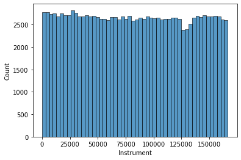

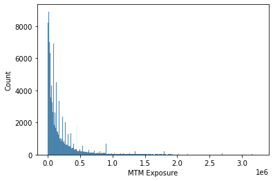

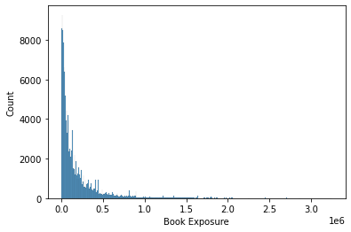

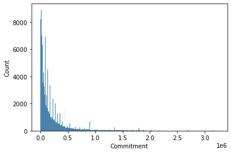

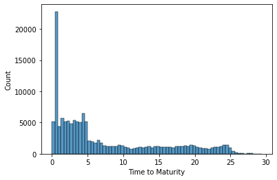

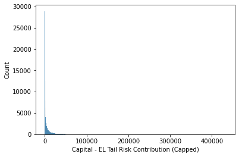

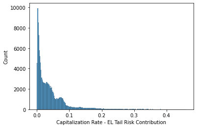

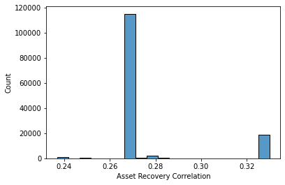

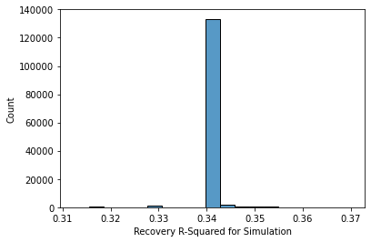

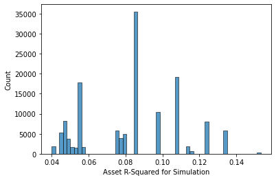

```python
for f in cont_feat:
    plt.figure()
    sns.histplot(df[f])
    plt.show()
```

##### We can see there is no normal distribution, and data is skewed

For data transformation, data should be positive as nagetive values might results worse performance. We will check for negative values in data.

```python
for f in num_feat:
    print("Fature name : {}, Negative Values : {}".format(f,len(df[df[f]<=0])))
```

```
Fature name : Instrument, Negative Values : 0
Fature name : MTM Exposure, Negative Values : 0
Fature name : Book Exposure, Negative Values : 0
Fature name : 1-Year Likelihood, Negative Values : 0
Fature name : Severity Used, Negative Values : 0
Fature name : Commitment, Negative Values : 0
Fature name : Time to Maturity, Negative Values : 0
Fature name : Capital - EL Tail Risk Contribution (Capped), Negative Values : 706
Fature name : Capitalization Rate - EL Tail Risk Contribution, Negative Values : 149
Fature name : Asset Recovery Correlation, Negative Values : 0
Fature name : Recovery R-Squared for Simulation, Negative Values : 0
Fature name : Asset R-Squared for Simulation, Negative Values : 0
```

```python
print(len(df[df["Capital - EL Tail Risk Contribution (Capped)"] <= 0])*100/len(df))
print(len(df[df["Capitalization Rate - EL Tail Risk Contribution"] <= 0])*100/len(df))
```

```
0.5099903202970368
0.10763251802302902
```

```python
print(df.shape) # Before dropping
df.drop(df[df["Capitalization Rate - EL Tail Risk Contribution"] <= 0].index,inplace=True)
df.drop(df[df["Capital - EL Tail Risk Contribution (Capped)"] <= 0].index,inplace=True)
print(df.shape) # After dropping
```

```
(138434, 23)
(137728, 23)
```

Let's check for skew coefficent. We will try Log, Squareroot and Box-Cox Transformation, choose which when perform best.

```python
from scipy import stats
for f in cont_feat:
    print("After Square Root Transformation : Skew Coefficient for column {} is {}.".format(f,df[f].skew()))
    print("After Log Transformation : Skew Coefficient for column {} is {}.".format(f,np.log(df[f]+1).skew()))
    print("After Box Cox : Skew Coefficient for column {} is {}.".format(f,pd.Series(stats.boxcox(df[f])[0]).skew()))
    print("\n--------------------\n")
```

```
After Square Root Transformation : Skew Coefficient for column Instrument is 0.016584342455597853.
After Log Transformation : Skew Coefficient for column Instrument is -1.9785419057007512.
After Box Cox : Skew Coefficient for column Instrument is -0.28951945521141825.

--------------------

After Square Root Transformation : Skew Coefficient for column MTM Exposure is 3.92479853914926.
After Log Transformation : Skew Coefficient for column MTM Exposure is -2.2975549694298336.
After Box Cox : Skew Coefficient for column MTM Exposure is 0.09832989566296721.

--------------------

After Square Root Transformation : Skew Coefficient for column Book Exposure is 3.9409636204485508.
After Log Transformation : Skew Coefficient for column Book Exposure is -2.2220895874446462.
After Box Cox : Skew Coefficient for column Book Exposure is 0.09789549939640715.

--------------------

After Square Root Transformation : Skew Coefficient for column Commitment is 3.924725687622084.
After Log Transformation : Skew Coefficient for column Commitment is -2.297451841700683.
After Box Cox : Skew Coefficient for column Commitment is 0.09832583126763302.

--------------------

After Square Root Transformation : Skew Coefficient for column Time to Maturity is 1.0135601974242354.
After Log Transformation : Skew Coefficient for column Time to Maturity is 0.0956885263561137.
After Box Cox : Skew Coefficient for column Time to Maturity is -0.06859234863140244.

--------------------

After Square Root Transformation : Skew Coefficient for column Capital - EL Tail Risk Contribution (Capped) is 7.578690219012743.
After Log Transformation : Skew Coefficient for column Capital - EL Tail Risk Contribution (Capped) is -0.6749741822104153.
After Box Cox : Skew Coefficient for column Capital - EL Tail Risk Contribution (Capped) is 0.008646521173949245.

--------------------

After Square Root Transformation : Skew Coefficient for column Capitalization Rate - EL Tail Risk Contribution is 3.0828943027206206.
After Log Transformation : Skew Coefficient for column Capitalization Rate - EL Tail Risk Contribution is 2.6979317599275916.
After Box Cox : Skew Coefficient for column Capitalization Rate - EL Tail Risk Contribution is -0.027932247746023757.

--------------------

After Square Root Transformation : Skew Coefficient for column Asset Recovery Correlation is 2.0262675666753416.
After Log Transformation : Skew Coefficient for column Asset Recovery Correlation is 2.0200103157579004.
After Box Cox : Skew Coefficient for column Asset Recovery Correlation is -0.7861460186787236.

--------------------

After Square Root Transformation : Skew Coefficient for column Recovery R-Squared for Simulation is 0.21236161364409836.
After Log Transformation : Skew Coefficient for column Recovery R-Squared for Simulation is 0.041946913633168215.
After Box Cox : Skew Coefficient for column Recovery R-Squared for Simulation is 0.12553612567015227.

--------------------

After Square Root Transformation : Skew Coefficient for column Asset R-Squared for Simulation is 0.12783556089502163.
After Log Transformation : Skew Coefficient for column Asset R-Squared for Simulation is 0.0882495208620112.
After Box Cox : Skew Coefficient for column Asset R-Squared for Simulation is -0.06952301059080929.

--------------------
```

```python
from scipy.special import boxcox, inv_boxcox
```

```python
## Transformation of Num features
```

```python
df.columns
```

```
Index(['Instrument', 'Instrument Type', 'Counterparty Alias', 'MTM Exposure',
       'Book Exposure', '1-Year Likelihood', 'Severity Used', 'Commitment',
       'Country of Incorporation', 'Maturity Date', 'Time to Maturity',
       'Capital - EL Tail Risk Contribution (Capped)',
       'Capitalization Rate - EL Tail Risk Contribution',
       'Asset Recovery Correlation', 'Recovery R-Squared for Simulation',
       'Asset R-Squared for Simulation',
       'Instrument Subtype_Term Loan Amortizing', 'Industry Alias_IND2',
       'Industry Alias_IND3', 'Industry Alias_IND5', 'Industry Alias_IND6',
       'Industry Alias_IND7', 'Industry Alias_IND8'],
      dtype='object')
```

We will only transform certain features which has worse distribution.

```python
trans_feats = ["MTM Exposure",
               "Book Exposure",
               "1-Year Likelihood",
               "Severity Used",
               "Commitment",
               "Time to Maturity",
               "Asset Recovery Correlation",
               "Asset R-Squared for Simulation",
              "Recovery R-Squared for Simulation"]
```

```python
trans_df = df.copy()
```

```python
trans_df.reset_index(inplace=True,drop=True)
```

```python
for f in trans_feats:
    trans_df[f] = pd.Series(stats.boxcox(trans_df[f])[0])
```

```python
trans_df["Capital - EL Tail Risk Contribution (Capped)"],y_lambda = stats.boxcox(trans_df["Capital - EL Tail Risk Contribution (Capped)"])
```

```python
trans_df.head()
```

|  | Instrument | Instrument Type | Counterparty Alias | MTM Exposure | Book Exposure | 1-Year Likelihood | Severity Used | Commitment | Country of Incorporation | Maturity Date | ... | Asset Recovery Correlation | Recovery R-Squared for Simulation | Asset R-Squared for Simulation | Instrument Subtype_Term Loan Amortizing | Industry Alias_IND2 | Industry Alias_IND3 | Industry Alias_IND5 | Industry Alias_IND6 | Industry Alias_IND7 | Industry Alias_IND8 |
| --- | --- | --- | --- | --- | --- | --- | --- | --- | --- | --- | --- | --- | --- | --- | --- | --- | --- | --- | --- | --- | --- |
| 0 | 86540 | Loan | C23099 | 46.531977 | 44.634201 | -1.968791 | -7.684066 | 46.529303 | CAN | 12/15/2037 | ... | -110515.263824 | -0.698409 | -1.253810 | 1 | 0 | 0 | 0 | 0 | 0 | 0 |
| 1 | 5738 | Loan | C11421 | 31.795491 | 30.723624 | -3.763748 | -16.477043 | 31.793986 | CAN | 11/17/2031 | ... | -11771.082033 | -0.699663 | -1.400509 | 1 | 1 | 0 | 0 | 0 | 0 | 0 |
| 2 | 165996 | Loan | C44251 | 38.052702 | 36.645806 | -6.164461 | -16.477043 | 38.050724 | CAN | 04/03/2028 | ... | -110515.263824 | -0.698409 | -1.228711 | 1 | 0 | 0 | 0 | 0 | 0 | 0 |
| 3 | 118169 | Loan | C53713 | 32.039924 | 30.955456 | -4.543722 | -2.196930 | 32.038401 | CAN | 01/03/2040 | ... | -11771.082033 | -0.699663 | -1.391769 | 1 | 0 | 0 | 0 | 0 | 0 | 0 |
| 4 | 25688 | Loan | C2146 | 41.871949 | 40.248805 | -6.164461 | -16.477043 | 41.869665 | CAN | 06/03/2030 | ... | -110515.263824 | -0.698409 | -1.228711 | 1 | 0 | 0 | 0 | 0 | 0 | 0 |

5 rows × 23 columns

Let's check for distribution.

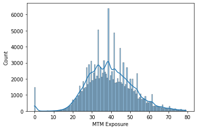

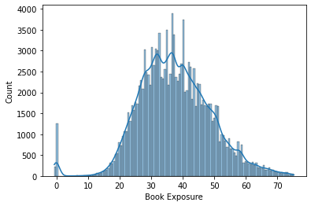

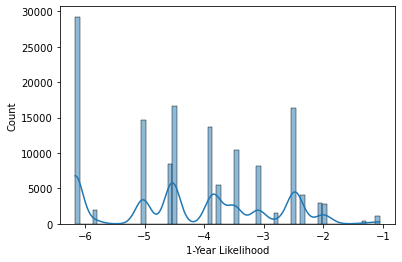

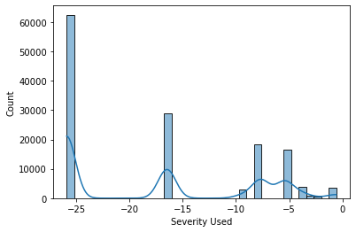

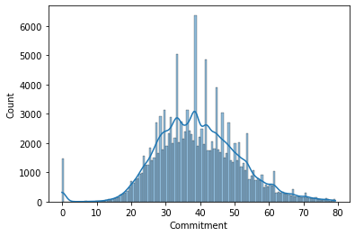

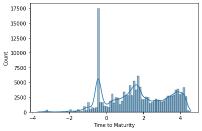

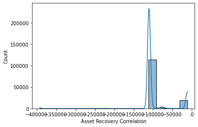

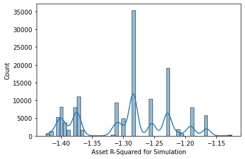

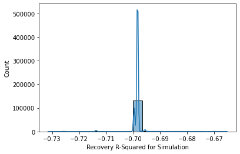

```python
for f in trans_feats:
    plt.figure()
    sns.histplot(trans_df[f],kde=True)
    plt.xlabel(f)
```

#### We can see distribution has been improved

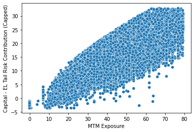

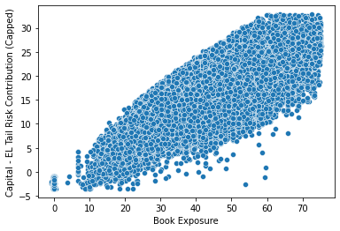

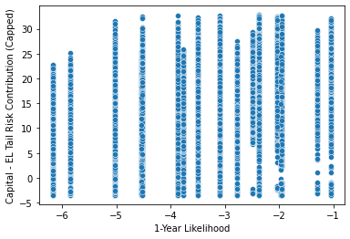

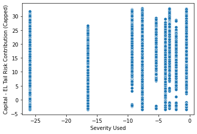

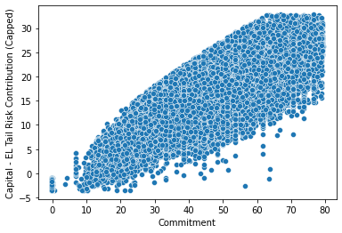

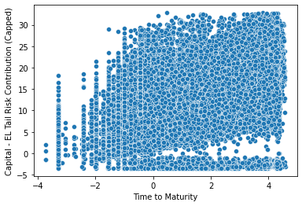

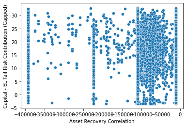

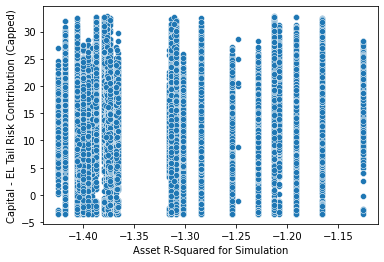

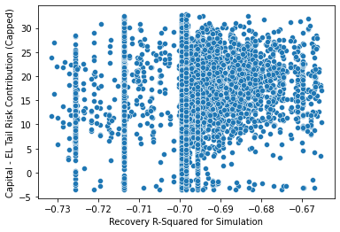

```python
for f in trans_feats:
    plt.figure()
    sns.scatterplot(x=trans_df[f],y=trans_df["Capital - EL Tail Risk Contribution (Capped)"])
```

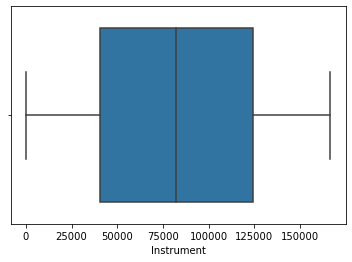

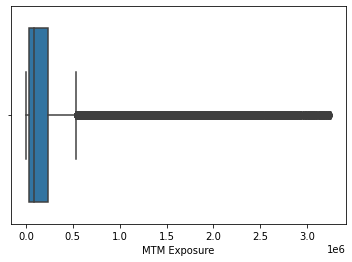

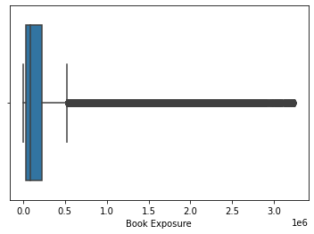

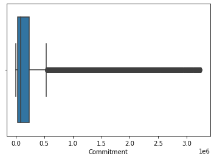

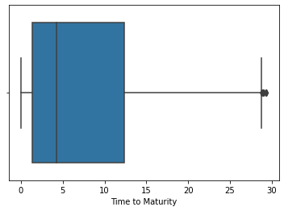

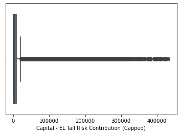

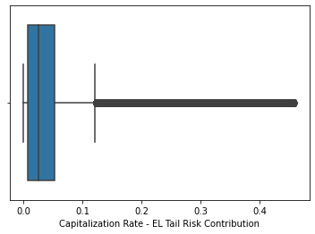

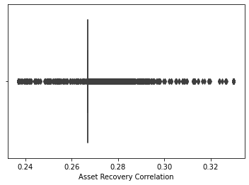

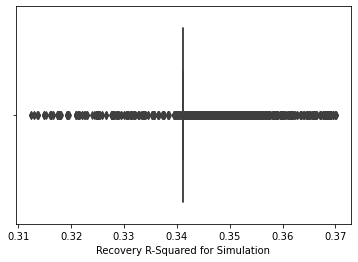

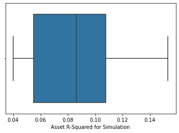

```python
for f in cont_feat:
    plt.figure()
    sns.boxplot(data=df, x= f)
    plt.show()
```

#### Let's prepare features for model

```python
trans_df.columns
```

```
Index(['Instrument', 'Instrument Type', 'Counterparty Alias', 'MTM Exposure',
       'Book Exposure', '1-Year Likelihood', 'Severity Used', 'Commitment',
       'Country of Incorporation', 'Maturity Date', 'Time to Maturity',
       'Capital - EL Tail Risk Contribution (Capped)',
       'Capitalization Rate - EL Tail Risk Contribution',
       'Asset Recovery Correlation', 'Recovery R-Squared for Simulation',
       'Asset R-Squared for Simulation',
       'Instrument Subtype_Term Loan Amortizing', 'Industry Alias_IND2',
       'Industry Alias_IND3', 'Industry Alias_IND5', 'Industry Alias_IND6',
       'Industry Alias_IND7', 'Industry Alias_IND8'],
      dtype='object')
```

```python
non_select = ['Instrument','Book Exposure','Country of Incorporation','Maturity Date','Recovery R-Squared for Simulation','Industry Alias',
              'Capital - EL Tail Risk Contribution (Capped)', 'Counterparty Alias','Capitalization Rate - EL Tail Risk Contribution',
              'Instrument Type',
             ]

# Capital - EL Tail Risk Contribution (Capped)', 'Capitalization Rate - EL Tail Risk Contribution'
# both are target features

#Country has just one category
#Maturity date has been already another feature called time to maturity.
#Counterparty alias contains string values which are not related to outcome.
```

- Capital - EL Tail Risk Contribution (Capped)' and 'Capitalization Rate - EL Tail Risk Contribution' both are target features, so we will exclude from input.
- 'Instrument' is unique indentifier column, so no need for that.
- 'Country' has just one category so we'll drop it
- 'Maturity date' has been already another feature called time to maturity.
- 'Counterparty alias' contains string values which are not related to outcome.
- 'Book Exposure' is correlated to MTM Exposure so we will not select
- 'Recovery R-Squared for Simulation' is already correlated to another independent feature.
- 'Instrument Type' has just one category so we'll drop that.

```python
X = trans_df[[f for f in df.columns if f not in non_select]]
X.head()
```

|  | MTM Exposure | 1-Year Likelihood | Severity Used | Commitment | Time to Maturity | Asset Recovery Correlation | Asset R-Squared for Simulation | Instrument Subtype_Term Loan Amortizing | Industry Alias_IND2 | Industry Alias_IND3 | Industry Alias_IND5 | Industry Alias_IND6 | Industry Alias_IND7 | Industry Alias_IND8 |
| --- | --- | --- | --- | --- | --- | --- | --- | --- | --- | --- | --- | --- | --- | --- |
| 0 | 46.531977 | -1.968791 | -7.684066 | 46.529303 | 3.583349 | -110515.263824 | -1.253810 | 1 | 0 | 0 | 0 | 0 | 0 | 0 |
| 1 | 31.795491 | -3.763748 | -16.477043 | 31.793986 | 2.864426 | -11771.082033 | -1.400509 | 1 | 1 | 0 | 0 | 0 | 0 | 0 |
| 2 | 38.052702 | -6.164461 | -16.477043 | 38.050724 | 2.242183 | -110515.263824 | -1.228711 | 1 | 0 | 0 | 0 | 0 | 0 | 0 |
| 3 | 32.039924 | -4.543722 | -2.196930 | 32.038401 | 3.775465 | -11771.082033 | -1.391769 | 1 | 0 | 0 | 0 | 0 | 0 | 0 |
| 4 | 41.871949 | -6.164461 | -16.477043 | 41.869665 | 2.640243 | -110515.263824 | -1.228711 | 1 | 0 | 0 | 0 | 0 | 0 | 0 |

```python
Y = trans_df['Capital - EL Tail Risk Contribution (Capped)']
```

```python
Y.head()
```

```
0    23.673970
1    12.108026
2    10.197612
3    14.341823
4    14.691864
Name: Capital - EL Tail Risk Contribution (Capped), dtype: float64
```

## Train Test Split

```python
from sklearn.model_selection import train_test_split
```

```python
X_train, X_test, y_train, y_test = train_test_split(X, Y, test_size=0.20, random_state=42)
```

```python
print(X_train.shape)
print(y_train.shape)
```

```
(110182, 14)
(110182,)
```

```python
print(X_test.shape)
print(y_test.shape)
```

```
(27546, 14)
(27546,)
```

## Standardization of Data

We will standardize the data now to same scale before giving input to data.

#### Here we are doing standardization after train_test_split, so we will fit our scaler on JUST training data and apply same scaler on testing data as well. Hence it will avoid Data Leakage.

```python
from sklearn.preprocessing import StandardScaler
```

```python
X_train.head()
```

|  | MTM Exposure | 1-Year Likelihood | Severity Used | Commitment | Time to Maturity | Asset Recovery Correlation | Asset R-Squared for Simulation | Instrument Subtype_Term Loan Amortizing | Industry Alias_IND2 | Industry Alias_IND3 | Industry Alias_IND5 | Industry Alias_IND6 | Industry Alias_IND7 | Industry Alias_IND8 |
| --- | --- | --- | --- | --- | --- | --- | --- | --- | --- | --- | --- | --- | --- | --- |
| 14500 | 50.713463 | -5.027237 | -25.902450 | 50.710426 | 1.455401 | -11771.082033 | -1.376424 | 0 | 0 | 0 | 0 | 0 | 0 | 0 |
| 86920 | 34.325559 | -6.164461 | -16.477043 | 34.323867 | 1.762440 | -110515.263824 | -1.228711 | 1 | 0 | 0 | 0 | 0 | 0 | 0 |
| 128105 | 46.573769 | -3.870960 | -25.902450 | 46.571092 | -0.277043 | -110515.263824 | -1.283956 | 0 | 0 | 0 | 0 | 0 | 0 | 0 |
| 59586 | 29.797134 | -6.164461 | -7.684066 | 29.795771 | 1.068969 | -110515.263824 | -1.302111 | 1 | 0 | 0 | 0 | 0 | 0 | 0 |
| 130346 | 46.573769 | -4.528920 | -25.902450 | 46.571092 | -0.993236 | -110515.263824 | -1.283956 | 0 | 0 | 0 | 0 | 0 | 0 | 0 |

```python
scaler = StandardScaler()
scaler.fit(X_train)
# We will fit scaler on training data and transform both training and testing data with same scaler to avoid data leakage.
```

```
StandardScaler()
```

```python
X_train = pd.DataFrame(scaler.transform(X_train),columns=X_train.columns)
```

```python
X_train.head()
```

|  | MTM Exposure | 1-Year Likelihood | Severity Used | Commitment | Time to Maturity | Asset Recovery Correlation | Asset R-Squared for Simulation | Instrument Subtype_Term Loan Amortizing | Industry Alias_IND2 | Industry Alias_IND3 | Industry Alias_IND5 | Industry Alias_IND6 | Industry Alias_IND7 | Industry Alias_IND8 |
| --- | --- | --- | --- | --- | --- | --- | --- | --- | --- | --- | --- | --- | --- | --- |
| 0 | 0.937694 | -0.589734 | -0.979447 | 0.937623 | -0.134780 | 2.121306 | -1.139859 | -1.593162 | -0.053631 | -0.057334 | -0.087701 | -0.112042 | -0.045135 | -0.050112 |
| 1 | -0.421982 | -1.425333 | 0.086363 | -0.422004 | 0.055344 | -0.311508 | 0.951875 | 0.627683 | -0.053631 | -0.057334 | -0.087701 | -0.112042 | -0.045135 | -0.050112 |
| 2 | 0.594231 | 0.259865 | -0.979447 | 0.594174 | -1.207540 | -0.311508 | 0.169563 | -1.593162 | -0.053631 | -0.057334 | -0.087701 | -0.112042 | -0.045135 | -0.050112 |
| 3 | -0.797698 | -1.425333 | 1.080659 | -0.797710 | -0.374065 | -0.311508 | -0.087522 | 0.627683 | -0.053631 | -0.057334 | -0.087701 | -0.112042 | -0.045135 | -0.050112 |
| 4 | 0.594231 | -0.223585 | -0.979447 | 0.594174 | -1.651019 | -0.311508 | 0.169563 | -1.593162 | -0.053631 | -0.057334 | -0.087701 | -0.112042 | -0.045135 | -0.050112 |

```python
X_test = pd.DataFrame(scaler.transform(X_test),columns=X_test.columns)
```

```python
X_test.head()
```

|  | MTM Exposure | 1-Year Likelihood | Severity Used | Commitment | Time to Maturity | Asset Recovery Correlation | Asset R-Squared for Simulation | Instrument Subtype_Term Loan Amortizing | Industry Alias_IND2 | Industry Alias_IND3 | Industry Alias_IND5 | Industry Alias_IND6 | Industry Alias_IND7 | Industry Alias_IND8 |
| --- | --- | --- | --- | --- | --- | --- | --- | --- | --- | --- | --- | --- | --- | --- |
| 0 | -0.384940 | -1.425333 | 1.503651 | -0.384963 | -0.003585 | -0.311508 | 0.596464 | 0.627683 | -0.053631 | -0.057334 | -0.087701 | -0.112042 | -0.045135 | -0.050112 |
| 1 | 1.453720 | 0.535182 | -0.979447 | 1.454376 | 1.085397 | -0.311508 | 0.169563 | 0.627683 | -0.053631 | -0.057334 | -0.087701 | -0.112042 | -0.045135 | -0.050112 |
| 2 | -0.831740 | -0.234461 | 0.086363 | -0.831751 | -0.307528 | -0.311508 | 0.951875 | 0.627683 | -0.053631 | -0.057334 | -0.087701 | -0.112042 | -0.045135 | -0.050112 |
| 3 | -0.506288 | 0.338641 | 0.086363 | -0.506308 | -0.217398 | 2.121306 | -0.253121 | -1.593162 | -0.053631 | -0.057334 | -0.087701 | -0.112042 | -0.045135 | -0.050112 |
| 4 | 0.347041 | -0.223585 | -0.979447 | 0.346993 | 0.462935 | -0.311508 | -1.108151 | 0.627683 | -0.053631 | -0.057334 | -0.087701 | -0.112042 | -0.045135 | -0.050112 |

### Linear Regression

Let's check for Linear regression model

```python
from sklearn.linear_model import LinearRegression
from sklearn.model_selection import cross_val_score
from sklearn.metrics import mean_absolute_error
```

```python
lin_reg = LinearRegression()
```

##### Cross validating Linear Regression Model on 5 sets. and checking R2.

```python
lin_reg_R2_in_CV = cross_val_score(lin_reg,X_train,y_train,scoring="r2",cv=5).mean()
```

```python
print(lin_reg_R2_in_CV)
```

```
0.900716482609391
```

##### Let's Train test model with training and testing data set

```python
lin_reg = LinearRegression()
```

```python
lin_reg.fit(X_train,y_train)
```

```
LinearRegression()
```

```python
lin_reg_Predictions = lin_reg.predict(X_test)
```

##### Let's check for Performance Metrics

```python
from sklearn.metrics import r2_score
```

##### This we are getting R2 score on Linear regression is 0.8895

```python
lin_reg_R2 = r2_score(lin_reg_Predictions, y_test)
lin_reg_R2
```

```
0.8895126696129878
```

##### We can see we are getting normal distribtuion for predicted values and are linearly distributed over scatter plot

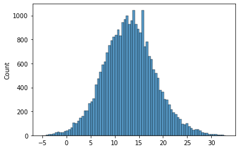

```python
sns.histplot(lin_reg_Predictions)
```

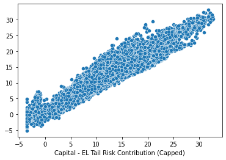

```python
sns.scatterplot(x=y_test, y=lin_reg_Predictions)
```

##### Now let's inverse box-cox transformations and check r2 again.

```python
r2_score(inv_boxcox(y_test,y_lambda),inv_boxcox(lin_reg_Predictions,y_lambda))
```

```
0.8441515747447843
```

### Ridge Regression

Now let's for Ridge regression

```python
from sklearn.linear_model import Ridge
from sklearn.model_selection import GridSearchCV
```

#### Cross validating Ridge regression on 5 Sets with different alpha values

```python
#param1 ={'alpha':[1e-15,1e-10,1e-8,1e-3,1e-2,1,5,10,20,30,35,40,45,50,55,100]}
ridge_reg = GridSearchCV(Ridge(),{'alpha':[1e-15,1e-10,1e-8,1e-3,1e-2,1,5,10,20,30,35,40,45,50,55,100]},scoring='r2',cv=5)
ridge_reg.fit(X_train,y_train)
```

```
GridSearchCV(cv=5, estimator=Ridge(),
             param_grid={'alpha': [1e-15, 1e-10, 1e-08, 0.001, 0.01, 1, 5, 10,
                                   20, 30, 35, 40, 45, 50, 55, 100]},
             scoring='r2')
```

```python
print(ridge_reg.best_params_)
```

```
{'alpha': 1e-08}
```

```python
print(ridge_reg.best_score_)
```

```
0.900716482635611
```

##### We are getting 0.9007 R2 score for Ridge Regression.

```python
ridge_reg_predictions = ridge_reg.predict(X_test)
```

```python
r2_score(y_test,ridge_reg_predictions)
```

```
0.8996915244293062
```

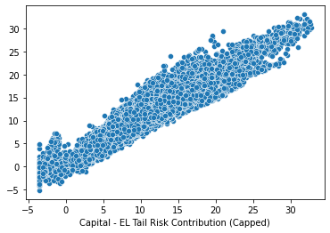

```python
sns.scatterplot(x=y_test, y=ridge_reg_predictions)
```

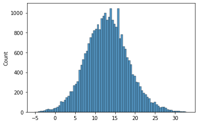

```python
sns.histplot(ridge_reg_predictions)
```

##### R2 score after inversing the transformation to orignal values

```python
r2_score(inv_boxcox(y_test,y_lambda),inv_boxcox(ridge_reg_predictions,y_lambda))
```

```
0.8441515792170847
```

### Lasso Regression

```python
from sklearn.linear_model import Lasso
from sklearn.model_selection import GridSearchCV
```

##### Cross Validating Lasso Regression on 5 sets with differet values of Alpha

```python
lasso_reg=GridSearchCV(Lasso(),{'alpha':[1e-15,1e-10,1e-8,1e-3,1e-2,1,5,10,20,30,35,40,45,50,55,100]},scoring='r2',cv=5)
```

```python
lasso_reg.fit(X_train,y_train)
```

[output not shown]

```
GridSearchCV(cv=5, estimator=Lasso(),
             param_grid={'alpha': [1e-15, 1e-10, 1e-08, 0.001, 0.01, 1, 5, 10,
                                   20, 30, 35, 40, 45, 50, 55, 100]},
             scoring='r2')
```

```python
print(lasso_reg.best_params_)
```

```
{'alpha': 1e-08}
```

```python
print(lasso_reg.best_score_)
```

```
0.9005618047598898
```

##### With Lasso Regression we are R2 score of 0.9005

```python
lasso_reg_predictions = lasso_reg.predict(X_test)
```

```python
r2_score(y_test,lasso_reg_predictions)
```

```
0.8995380670271294
```

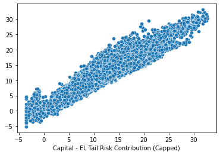

```python
sns.scatterplot(x=y_test, y=lasso_reg_predictions)
```

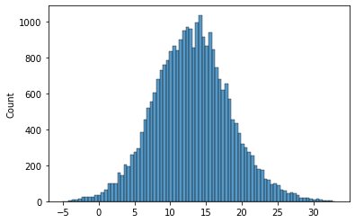

```python
sns.histplot(lasso_reg_predictions)
```

##### R2 score after inversing transformation

```python
r2_score(inv_boxcox(y_test,y_lambda),inv_boxcox(lasso_reg_predictions,y_lambda))
```

```
0.8439770771694235
```

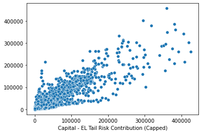

```python
sns.scatterplot(x=inv_boxcox(y_test,y_lambda),y=inv_boxcox(lasso_reg_predictions,y_lambda))
```

### Decision Tree

```python
from sklearn.tree import DecisionTreeRegressor

# create a regressor object
DTree = DecisionTreeRegressor(random_state = 0)
```

```python
DTree.fit(X_train, y_train)
```

```
DecisionTreeRegressor(random_state=0)
```

```python
DTree_Predictions =  DTree.predict(X_test)
```

```python
r2_score(y_test,DTree_Predictions)
```

```
0.8858262907747837
```

```python
r2_score(inv_boxcox(y_test,y_lambda),inv_boxcox(DTree_Predictions,y_lambda))
```

```
0.870816270983169
```

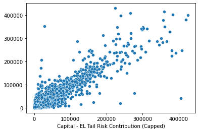

```python
sns.scatterplot(x=inv_boxcox(y_test,y_lambda),y=inv_boxcox(DTree_Predictions,y_lambda))
```

#### Random Forest

```python
from sklearn.ensemble import RandomForestRegressor
R_Forest = RandomForestRegressor(n_estimators = 100, random_state = 0)
```

```python
R_Forest.fit(X_train,y_train)
```

```
RandomForestRegressor(random_state=0)
```

```python
R_Forest_Predictions = R_Forest.predict(X_test)
```

```python
r2_score(y_test,R_Forest_Predictions)
```

```
0.935180611892234
```

```python
r2_score(inv_boxcox(y_test,y_lambda),inv_boxcox(R_Forest_Predictions,y_lambda))
```

```
0.9339733900910265
```

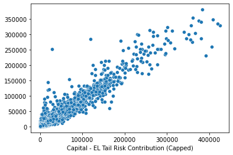

```python
sns.scatterplot(x=inv_boxcox(y_test,y_lambda),y=inv_boxcox(R_Forest_Predictions,y_lambda))
```

### Neural Network

```python
import tensorflow as tf
from tensorflow import keras
```

```python
from keras.models import Sequential
from keras.layers import Dense
```

```python
X_train.shape
```

```
(110182, 14)
```

```python
from keras.models import Sequential
from keras.layers import Dense
model = Sequential()
model.add(Dense(units=5, input_dim=14, kernel_initializer='normal', activation='relu'))
model.add(Dense(1, kernel_initializer='normal'))
model.compile(loss='mean_squared_error', optimizer='adam')
model.fit(X_train, y_train ,batch_size = 20, epochs = 10, verbose=1)
```

```
<tensorflow.python.keras.callbacks.History at 0x1b71c7efc40>
```

```python
aa=model.predict(X_test)
```

```python
r2_score(y_test,aa)
```

```
0.9109496574895728
```

```python
r2_score(y_test,aa)
r2_score(inv_boxcox(y_test,y_lambda),inv_boxcox(aa,y_lambda))
```

```
0.802072951739382
```

## Output Data to CSV

#### Saving Development Data to CSV

First get our raw dataframe with non-transformed values and without encoded columns to save to CSV

```python
non_trans = df.copy()
```

```python
non_trans.reset_index(inplace=True)
non_trans = non_trans.drop(["index"],axis=1)
```

##### Dropping encoded columns before saving to CSV

```python
non_trans = non_trans.drop([f for f in non_trans.columns if f in encoded_cols],axis=1)
```

```python
non_trans.head()
```

|  | Instrument | Instrument Type | Counterparty Alias | MTM Exposure | Book Exposure | 1-Year Likelihood | Severity Used | Commitment | Country of Incorporation | Maturity Date | Time to Maturity | Capital - EL Tail Risk Contribution (Capped) | Capitalization Rate - EL Tail Risk Contribution | Asset Recovery Correlation | Recovery R-Squared for Simulation | Asset R-Squared for Simulation |
| --- | --- | --- | --- | --- | --- | --- | --- | --- | --- | --- | --- | --- | --- | --- | --- | --- |
| 0 | 86540 | Loan | C23099 | 224013.330 | 224013.33 | 0.160200 | 0.057 | 224013.33 | CAN | 12/15/2037 | 16.375086 | 57797.73 | 0.258010 | 0.26706 | 0.34109 | 0.0976 |
| 1 | 5738 | Loan | C11421 | 36190.953 | 36190.95 | 0.036900 | 0.019 | 36190.95 | CAN | 11/17/2031 | 10.297057 | 1558.02 | 0.043050 | 0.33000 | 0.34000 | 0.0469 |
| 2 | 165996 | Loan | C44251 | 84600.000 | 84600.00 | 0.006525 | 0.019 | 84600.00 | CAN | 04/03/2028 | 6.674880 | 703.86 | 0.008320 | 0.26706 | 0.34109 | 0.1077 |
| 3 | 118169 | Loan | C53713 | 37508.787 | 37508.78 | 0.020475 | 0.247 | 37508.78 | CAN | 01/03/2040 | 18.425736 | 3602.36 | 0.096041 | 0.33000 | 0.34000 | 0.0495 |
| 4 | 25688 | Loan | C2146 | 134033.940 | 134033.94 | 0.006525 | 0.019 | 134033.94 | CAN | 06/03/2030 | 8.840520 | 4076.59 | 0.030415 | 0.26706 | 0.34109 | 0.1077 |

# Run whole DEVELOPMENT dataset on our best Model (Random Forest) and predict values

```python
X.head()
```

|  | MTM Exposure | 1-Year Likelihood | Severity Used | Commitment | Time to Maturity | Asset Recovery Correlation | Asset R-Squared for Simulation | Instrument Subtype_Term Loan Amortizing | Industry Alias_IND2 | Industry Alias_IND3 | Industry Alias_IND5 | Industry Alias_IND6 | Industry Alias_IND7 | Industry Alias_IND8 |
| --- | --- | --- | --- | --- | --- | --- | --- | --- | --- | --- | --- | --- | --- | --- |
| 0 | 46.531977 | -1.968791 | -7.684066 | 46.529303 | 3.583349 | -110515.263824 | -1.253810 | 1 | 0 | 0 | 0 | 0 | 0 | 0 |
| 1 | 31.795491 | -3.763748 | -16.477043 | 31.793986 | 2.864426 | -11771.082033 | -1.400509 | 1 | 1 | 0 | 0 | 0 | 0 | 0 |
| 2 | 38.052702 | -6.164461 | -16.477043 | 38.050724 | 2.242183 | -110515.263824 | -1.228711 | 1 | 0 | 0 | 0 | 0 | 0 | 0 |
| 3 | 32.039924 | -4.543722 | -2.196930 | 32.038401 | 3.775465 | -11771.082033 | -1.391769 | 1 | 0 | 0 | 0 | 0 | 0 | 0 |
| 4 | 41.871949 | -6.164461 | -16.477043 | 41.869665 | 2.640243 | -110515.263824 | -1.228711 | 1 | 0 | 0 | 0 | 0 | 0 | 0 |

```python
Y.head()
```

```
0    23.673970
1    12.108026
2    10.197612
3    14.341823
4    14.691864
Name: Capital - EL Tail Risk Contribution (Capped), dtype: float64
```

```python
X_DEV = pd.DataFrame(scaler.transform(X),columns=X.columns)
```

```python
Y_DEV_RF = inv_boxcox(R_Forest.predict(X_DEV),y_lambda)
```

```python
r2_DEV_RF = r2_score((inv_boxcox(Y,y_lambda)),Y_DEV_RF)
```

```python
print(r2_DEV_RF)
```

```
0.9788549111988313
```

##### Let's save devlopment set with predicted values from Random Forest to CSV.

```python
Dev_RandomForest = non_trans.copy()
```

Calculating Capitalization Rate

```python
Dev_RandomForest["Predicted Capitalization Rate"] = Y_DEV_RF/Dev_RandomForest["MTM Exposure"]
```

```python
Dev_RandomForest["Predicted Capital"] = Y_DEV_RF
```

```python
Dev_RandomForest.head()
```

|  | Instrument | Instrument Type | Counterparty Alias | MTM Exposure | Book Exposure | 1-Year Likelihood | Severity Used | Commitment | Country of Incorporation | Maturity Date | Time to Maturity | Capital - EL Tail Risk Contribution (Capped) | Capitalization Rate - EL Tail Risk Contribution | Asset Recovery Correlation | Recovery R-Squared for Simulation | Asset R-Squared for Simulation | Predicted Capitalization Rate | Predicted Capital |
| --- | --- | --- | --- | --- | --- | --- | --- | --- | --- | --- | --- | --- | --- | --- | --- | --- | --- | --- |
| 0 | 86540 | Loan | C23099 | 224013.330 | 224013.33 | 0.160200 | 0.057 | 224013.33 | CAN | 12/15/2037 | 16.375086 | 57797.73 | 0.258010 | 0.26706 | 0.34109 | 0.0976 | 0.221940 | 49717.627863 |
| 1 | 5738 | Loan | C11421 | 36190.953 | 36190.95 | 0.036900 | 0.019 | 36190.95 | CAN | 11/17/2031 | 10.297057 | 1558.02 | 0.043050 | 0.33000 | 0.34000 | 0.0469 | 0.041416 | 1498.890011 |
| 2 | 165996 | Loan | C44251 | 84600.000 | 84600.00 | 0.006525 | 0.019 | 84600.00 | CAN | 04/03/2028 | 6.674880 | 703.86 | 0.008320 | 0.26706 | 0.34109 | 0.1077 | 0.008585 | 726.312685 |
| 3 | 118169 | Loan | C53713 | 37508.787 | 37508.78 | 0.020475 | 0.247 | 37508.78 | CAN | 01/03/2040 | 18.425736 | 3602.36 | 0.096041 | 0.33000 | 0.34000 | 0.0495 | 0.103448 | 3880.203038 |
| 4 | 25688 | Loan | C2146 | 134033.940 | 134033.94 | 0.006525 | 0.019 | 134033.94 | CAN | 06/03/2030 | 8.840520 | 4076.59 | 0.030415 | 0.26706 | 0.34109 | 0.1077 | 0.007014 | 940.151254 |

```python
Dev_RandomForest.to_csv('Dev_RandomForest.csv')
```

```python
r2_score(Dev_RandomForest['Capitalization Rate - EL Tail Risk Contribution'],Dev_RandomForest["Predicted Capitalization Rate"])
```

```
0.9584939634054673
```

```python
r2_score(Dev_RandomForest['Capital - EL Tail Risk Contribution (Capped)'],Dev_RandomForest["Predicted Capital"])
```

```
0.9788549111988313
```

# Run whole HOLD OUT TEST dataset on our best model (Random Forest) and predict values

### Preprocessing Holdout Test Data

```python
df_holdout = pd.read_csv("Holdout Test - Actuals Removed.csv")
```

```python
df_holdout.head()
```

|  | Instrument | Instrument Type | Instrument Subtype | Counterparty Alias | MTM Exposure | Book Exposure | 1-Year Likelihood | Severity Used | Industry Alias | Commitment | Country of Incorporation | Maturity Date | Time to Maturity | Capital - EL Tail Risk Contribution (Capped) | Capitalization Rate - EL Tail Risk Contribution | Asset Recovery Correlation | Recovery R-Squared for Simulation | Asset R-Squared for Simulation |
| --- | --- | --- | --- | --- | --- | --- | --- | --- | --- | --- | --- | --- | --- | --- | --- | --- | --- | --- |
| 0 | 49146 | Loan | Term Loan Amortizing | C13207 | 89465.73891 | 89518.73 | 0.006525 | 0.1330 | IND1 | 89518.73 | CAN | 02/16/2037 | 15.548255 | NaN | NaN | 0.33000 | 0.34000 | 0.0484 |
| 1 | 62941 | Loan | Term Loan Amortizing | C34003 | 42068.35800 | 42068.35 | 0.033975 | 0.0095 | IND1 | 42068.35 | CAN | 11/25/2026 | 5.319644 | NaN | NaN | 0.26706 | 0.34109 | 0.0549 |
| 2 | 87386 | Loan | Term Loan Amortizing | C93 | 31293.97200 | 31293.97 | 0.006525 | 0.0190 | IND1 | 31293.97 | CAN | 04/01/2024 | 2.669405 | NaN | NaN | 0.26706 | 0.34109 | 0.1077 |
| 3 | 148592 | Loan | Term Loan Amortizing | C51685 | 810000.00000 | 810000.00 | 0.014400 | 0.6080 | IND5 | 810000.00 | CAN | 01/02/2032 | 10.422998 | NaN | NaN | 0.25273 | 0.34550 | 0.0532 |
| 4 | 84761 | Loan | Term Loan Amortizing | C49430 | 256009.86000 | 256009.86 | 0.062550 | 0.0570 | IND1 | 256009.86 | CAN | 10/01/2038 | 17.169062 | NaN | NaN | 0.26706 | 0.34109 | 0.0549 |

```python
df_holdout.shape
```

```
(15000, 18)
```

Dropping Removed Target Columns which are Null.

```python
df_holdout.drop([ 'Capital - EL Tail Risk Contribution (Capped)','Capitalization Rate - EL Tail Risk Contribution'],axis=1,inplace=True)
```

```python
df_holdout.head()
```

|  | Instrument | Instrument Type | Instrument Subtype | Counterparty Alias | MTM Exposure | Book Exposure | 1-Year Likelihood | Severity Used | Industry Alias | Commitment | Country of Incorporation | Maturity Date | Time to Maturity | Asset Recovery Correlation | Recovery R-Squared for Simulation | Asset R-Squared for Simulation |
| --- | --- | --- | --- | --- | --- | --- | --- | --- | --- | --- | --- | --- | --- | --- | --- | --- |
| 0 | 49146 | Loan | Term Loan Amortizing | C13207 | 89465.73891 | 89518.73 | 0.006525 | 0.1330 | IND1 | 89518.73 | CAN | 02/16/2037 | 15.548255 | 0.33000 | 0.34000 | 0.0484 |
| 1 | 62941 | Loan | Term Loan Amortizing | C34003 | 42068.35800 | 42068.35 | 0.033975 | 0.0095 | IND1 | 42068.35 | CAN | 11/25/2026 | 5.319644 | 0.26706 | 0.34109 | 0.0549 |
| 2 | 87386 | Loan | Term Loan Amortizing | C93 | 31293.97200 | 31293.97 | 0.006525 | 0.0190 | IND1 | 31293.97 | CAN | 04/01/2024 | 2.669405 | 0.26706 | 0.34109 | 0.1077 |
| 3 | 148592 | Loan | Term Loan Amortizing | C51685 | 810000.00000 | 810000.00 | 0.014400 | 0.6080 | IND5 | 810000.00 | CAN | 01/02/2032 | 10.422998 | 0.25273 | 0.34550 | 0.0532 |
| 4 | 84761 | Loan | Term Loan Amortizing | C49430 | 256009.86000 | 256009.86 | 0.062550 | 0.0570 | IND1 | 256009.86 | CAN | 10/01/2038 | 17.169062 | 0.26706 | 0.34109 | 0.0549 |

We will perform same preprocessing for this set as well.

Missing values

```python
df_holdout.isna().sum()
```

```
Instrument                           0
Instrument Type                      0
Instrument Subtype                   3
Counterparty Alias                   0
MTM Exposure                         0
Book Exposure                        0
1-Year Likelihood                    0
Severity Used                        0
Industry Alias                       0
Commitment                           0
Country of Incorporation             0
Maturity Date                        0
Time to Maturity                     0
Asset Recovery Correlation           0
Recovery R-Squared for Simulation    0
Asset R-Squared for Simulation       0
dtype: int64
```

```python
df_holdout.dropna(inplace=True)
```

```python
df_holdout.shape
```

```
(14997, 16)
```

Clearing outliers

```python
outlier_feats = ['MTM Exposure','1-Year Likelihood'
                 ,'Severity Used','Commitment',
                 #'Capital - EL Tail Risk Contribution (Capped)',
               #'Capitalization Rate - EL Tail Risk Contribution',
                 'Asset Recovery Correlation', 'Time to Maturity',
       'Asset R-Squared for Simulation','Recovery R-Squared for Simulation']
```

We will use Z-Score technique to handle outliers.

```python
from scipy import stats
import numpy as np
z_scores_h = np.abs(stats.zscore(df_holdout[outlier_feats]))
```

```python
print(df_holdout.shape)
```

```
(14997, 16)
```

```python
df_holdout_clean = df_holdout.copy()
```

```python
df_holdout_clean = df_holdout_clean[(z_scores_h < 3).all(axis=1)]
```

```python
print(df_holdout_clean.shape)
```

```
(13770, 16)
```

```python
num_feat_h = [f for f in df_holdout.columns if df_holdout[f].dtype != "O"]
```

```python
cont_feat_h = [f for f in num_feat_h if df_holdout[f].unique().sum() > 25]
```

```python
finite_features_h = [f for f in num_feat_h if len(df_holdout[f].unique()) <= 30]
```

```python
categorical_feat_h = ["Instrument Type","Instrument Subtype","Industry Alias", "Country of Incorporation"]
```

Handling Categorical Features

```python
for f in categorical_feat_h:
    print("No of Categories in {} are {}".format(f,len(df_holdout_clean[f].unique())))
```

```
No of Categories in Instrument Type are 1
No of Categories in Instrument Subtype are 2
No of Categories in Industry Alias are 20
No of Categories in Country of Incorporation are 1
```

```python
categorical_feat_h = ["Instrument Subtype","Industry Alias"]
```

```python
df_holdout_clean = df_holdout_clean[df_holdout_clean["Industry Alias"].map(df_holdout_clean["Industry Alias"].value_counts()) > 30]
```

```python
df_holdout_clean["Industry Alias"].value_counts()
```

```
IND1    13271
IND6      163
IND5      117
IND7       48
IND3       42
IND2       38
IND8       34
Name: Industry Alias, dtype: int64
```

```python
df_holdout_clean = pd.get_dummies(df_holdout_clean,prefix=['Instrument Subtype','Industry Alias'], columns = ['Instrument Subtype','Industry Alias'], drop_first=True)
```

```python
encoded_cols_h =[f for f in df_holdout_clean.columns if "_" in f]
encoded_cols_h
```

```
['Instrument Subtype_Term Loan Amortizing',
 'Industry Alias_IND2',
 'Industry Alias_IND3',
 'Industry Alias_IND5',
 'Industry Alias_IND6',
 'Industry Alias_IND7',
 'Industry Alias_IND8']
```

Handling Numerical Features

```python
num_feat_h = [f for f in df_holdout_clean.columns if (df_holdout_clean[f].dtype!="O") and f not in encoded_cols_h]
finite_features_h = [f for f in num_feat_h if len(df_holdout_clean[f].unique()) <= 30]
cont_feat_h = [f for f in num_feat_h if f not in finite_features_h]
```

Features that needs to be transformed

```python
trans_feats_h = ["MTM Exposure",
               "Book Exposure",
               "1-Year Likelihood",
               "Severity Used",
               "Commitment",
               "Time to Maturity",
               "Asset Recovery Correlation",
               "Asset R-Squared for Simulation",
              "Recovery R-Squared for Simulation"]
```

```python
df_holdout_trans = df_holdout_clean.copy()
```

```python
df_holdout_trans.reset_index(inplace=True,drop=True)
```

```python
for f in trans_feats_h:
    df_holdout_trans[f] = pd.Series(stats.boxcox(df_holdout_trans[f])[0])
```

Selecting Features for the model

```python
non_select_h = ['Instrument','Book Exposure','Country of Incorporation','Maturity Date','Recovery R-Squared for Simulation','Industry Alias',
              'Capital - EL Tail Risk Contribution (Capped)', 'Counterparty Alias','Capitalization Rate - EL Tail Risk Contribution',
              'Instrument Type',
             ]
```

```python
df_holdout_X = df_holdout_trans[[f for f in df_holdout_trans.columns if f not in non_select]]
```

Standardizing that Data

```python
df_holdout_X = pd.DataFrame(scaler.transform(df_holdout_X),columns=df_holdout_X.columns)
```

```python
df_holdout_X.head()
```

|  | MTM Exposure | 1-Year Likelihood | Severity Used | Commitment | Time to Maturity | Asset Recovery Correlation | Asset R-Squared for Simulation | Instrument Subtype_Term Loan Amortizing | Industry Alias_IND2 | Industry Alias_IND3 | Industry Alias_IND5 | Industry Alias_IND6 | Industry Alias_IND7 | Industry Alias_IND8 |
| --- | --- | --- | --- | --- | --- | --- | --- | --- | --- | --- | --- | --- | --- | --- |
| 0 | 0.238760 | -1.365942 | 1.506142 | 0.239234 | 1.169725 | 2.167544 | -2.304055 | 0.627683 | -0.053631 | -0.057334 | -0.087701 | -0.112042 | -0.045135 | -0.050112 |
| 1 | -0.299841 | 0.284498 | -0.935022 | -0.299817 | 0.174275 | 0.204125 | -1.964555 | 0.627683 | -0.053631 | -0.057334 | -0.087701 | -0.112042 | -0.045135 | -0.050112 |
| 2 | -0.490314 | -1.365942 | 0.109578 | -0.490289 | -0.370099 | 0.204125 | 0.319286 | 0.627683 | -0.053631 | -0.057334 | -0.087701 | -0.112042 | -0.045135 | -0.050112 |
| 3 | 2.351756 | -0.549255 | 1.884007 | 2.351745 | 0.775572 | -1.508018 | -2.051555 | 0.627683 | -0.053631 | -0.057334 | 11.402328 | -0.112042 | -0.045135 | -0.050112 |
| 4 | 1.134571 | 0.846255 | 1.087982 | 1.134581 | 1.271987 | 0.204125 | -1.964555 | 0.627683 | -0.053631 | -0.057334 | -0.087701 | -0.112042 | -0.045135 | -0.050112 |

#### Now we have Preprocessed Data we can pass it to our model and predict values

### Random Forest on Holdout Dataset

```python
Y_TEST_RF = inv_boxcox(R_Forest.predict(df_holdout_X),y_lambda)
```

```python
Y_TEST_RF
```

```
array([4583.30855274,  904.38502531,  310.94737882, ...,   82.95665593,
       1642.96110032,  145.92032128])
```

#### Save to CSV file

"df_holdout_clean" is our orignal and un-transformed cleaned Holdout test data. So we will add our predictions here and export.

```python
df_holdout_clean = df_holdout_clean.drop([f for f in df_holdout_clean.columns if f in encoded_cols],axis=1)
```

```python
df_holdout_clean.head()
```

|  | Instrument | Instrument Type | Counterparty Alias | MTM Exposure | Book Exposure | 1-Year Likelihood | Severity Used | Commitment | Country of Incorporation | Maturity Date | Time to Maturity | Asset Recovery Correlation | Recovery R-Squared for Simulation | Asset R-Squared for Simulation |
| --- | --- | --- | --- | --- | --- | --- | --- | --- | --- | --- | --- | --- | --- | --- |
| 0 | 49146 | Loan | C13207 | 89465.73891 | 89518.73 | 0.006525 | 0.1330 | 89518.73 | CAN | 02/16/2037 | 15.548255 | 0.33000 | 0.34000 | 0.0484 |
| 1 | 62941 | Loan | C34003 | 42068.35800 | 42068.35 | 0.033975 | 0.0095 | 42068.35 | CAN | 11/25/2026 | 5.319644 | 0.26706 | 0.34109 | 0.0549 |
| 2 | 87386 | Loan | C93 | 31293.97200 | 31293.97 | 0.006525 | 0.0190 | 31293.97 | CAN | 04/01/2024 | 2.669405 | 0.26706 | 0.34109 | 0.1077 |
| 3 | 148592 | Loan | C51685 | 810000.00000 | 810000.00 | 0.014400 | 0.6080 | 810000.00 | CAN | 01/02/2032 | 10.422998 | 0.25273 | 0.34550 | 0.0532 |
| 4 | 84761 | Loan | C49430 | 256009.86000 | 256009.86 | 0.062550 | 0.0570 | 256009.86 | CAN | 10/01/2038 | 17.169062 | 0.26706 | 0.34109 | 0.0549 |

```python
df_holdout_clean.reset_index(inplace=True,drop=True)
```

```python
Test_RF = df_holdout_clean.copy()
```

```python
Test_RF["Predicted Capitalization Rate"] = Y_TEST_RF/Test_RF["MTM Exposure"]
```

```python
Test_RF["Predicted Capital"] = Y_TEST_RF
```

```python
Test_RF.head()
```

|  | Instrument | Instrument Type | Counterparty Alias | MTM Exposure | Book Exposure | 1-Year Likelihood | Severity Used | Commitment | Country of Incorporation | Maturity Date | Time to Maturity | Asset Recovery Correlation | Recovery R-Squared for Simulation | Asset R-Squared for Simulation | Predicted Capitalization Rate | Predicted Capital |
| --- | --- | --- | --- | --- | --- | --- | --- | --- | --- | --- | --- | --- | --- | --- | --- | --- |
| 0 | 49146 | Loan | C13207 | 89465.73891 | 89518.73 | 0.006525 | 0.1330 | 89518.73 | CAN | 02/16/2037 | 15.548255 | 0.33000 | 0.34000 | 0.0484 | 0.051230 | 4583.308553 |
| 1 | 62941 | Loan | C34003 | 42068.35800 | 42068.35 | 0.033975 | 0.0095 | 42068.35 | CAN | 11/25/2026 | 5.319644 | 0.26706 | 0.34109 | 0.0549 | 0.021498 | 904.385025 |
| 2 | 87386 | Loan | C93 | 31293.97200 | 31293.97 | 0.006525 | 0.0190 | 31293.97 | CAN | 04/01/2024 | 2.669405 | 0.26706 | 0.34109 | 0.1077 | 0.009936 | 310.947379 |
| 3 | 148592 | Loan | C51685 | 810000.00000 | 810000.00 | 0.014400 | 0.6080 | 810000.00 | CAN | 01/02/2032 | 10.422998 | 0.25273 | 0.34550 | 0.0532 | 0.269478 | 218276.822123 |
| 4 | 84761 | Loan | C49430 | 256009.86000 | 256009.86 | 0.062550 | 0.0570 | 256009.86 | CAN | 10/01/2038 | 17.169062 | 0.26706 | 0.34109 | 0.0549 | 0.144403 | 36968.550816 |

```python
Test_RF.to_csv('Test_RF.csv')
```